# act_report

## Report: act_report

Insights:

The first visual I created was a bar chart too see which dog noun was most common in tweets. The 5 labels were None, Doggo, Floofer, Pupper, and Puppo. We could clearly see that most tweets had no noun used, the most common noun used (1828) was Pupper (234), followed by Doggo (75), Puppo (25) and Floofer (10).

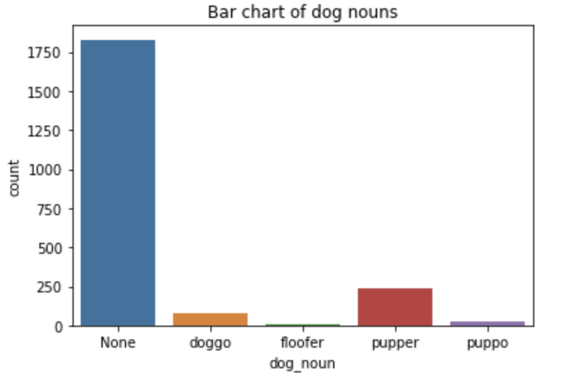

My third graph is a scatter graph that compares the number of retweets against the number of favourites that a tweet receives. Here, we can see that there is a strong positive correlation between these two variables. This was verified by the correlation coefficient which received a score of 0.926.

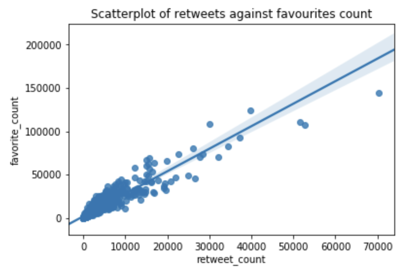

The final insight that I created was a bar chart of the dog breeds that had the highest number of initial predictions. The bar chart contained the top 10 breeds. We could see that the golden retriever was the most popular first prediction of the twitter image with over 130. Then there was a Labrador Retriever with the second highest, and a Pembroke in third.

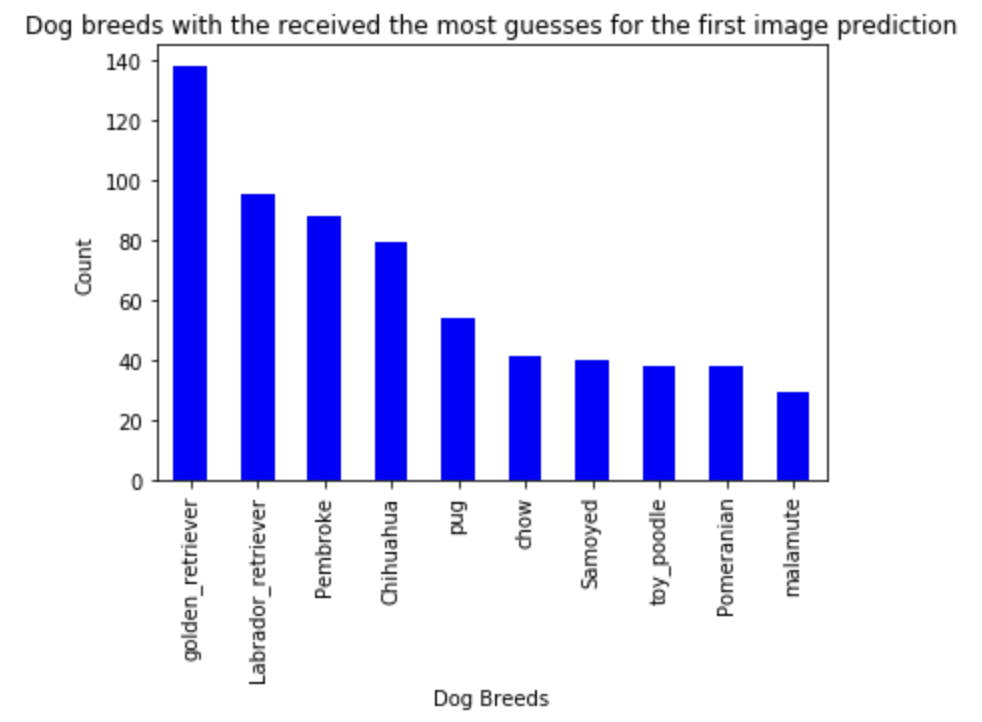